# Mini Project 2

Sana Choudhry

2024-04-16

## Introduction

We want to analyze, is the number of days physical health was not good greater in males compred to females? This question aims to evaluate if there is a statistically significant difference in self-reported poor physical health days between male and female respondents in the Behavioral Risk Factor Surveillance System (BRFSS). Understanding differences in physical health across genders is crucial for multiple reasons. Firstly, it can help public health professionals identify gender-specific health issues and barriers to health that may not be apparent without such targeted analysis. Secondly, it can guide the allocation of resources that will be more tailored and therefore potentially more effective in addressing the specific needs of different demographic groups. The primary stakeholders in this research include:

- Public Health Authorities
- Healthcare Providers
- Policy Makers
- Researchers
- General Public

The results of this analysis could significantly impact patient care in hospitals, clinics, and other health institutions by informing gender-sensitive health practices and interventions. If, for example, a significant difference in physical health days is found between genders, healthcare institutions might consider implementing gender-specific health screenings or preventive health programs.  
Institutions could also use this information to train healthcare providers on gender difference in health perceptions and management. This could lead to improved patient outcomes, higher patient satisfaction, and more effective management of public health resources.  
Overall, by tailoring health interventions to meet the specific needs of different demographic groups, health systems can improve the efficacy of their programs and the health of the communities they serve.

## Data Cleaning & Exploratory Data Analysis

The analysis utilizes data from the Behavior Risk Factor Surveillance System (BRFSS), which is a comprehensive telephone survey conducted by the Centers for Disease Control and Prevention (CDC). The BRFSS gathers state-level data about U.S. residents regarding their health-related risk behaviors, chronic health conditions, an use of medical services. BRFSS data is collected annually, and the methods and strategies for handling the data are consistent across different years.  
1. The variable ‘PHYSHLTH’, which measures the “Number of Days Physical Health Was Not Good”, initially included specific numeric codes for non-numeric responses (88 for “None”, 77 for “Don’t know/Not sure”, and 99 for “Refused”). These were recorded to NA (missing values) to ensure that the variable only contained numeric data relevant to the analysis.  
2. The recoding of this variable was verified by comparing the frequency of these specific responses before and after the recoding process. This check confirmed that values meant to be recoded were successfully transformed into ‘NA’.  
3. The original ‘SEX’ variable, coded as 1 for males and 2 for females, was recoded into a new variable ‘SEX2’ with more descriptive labels: “Male” and “Female”. This recoding enhances the readability of the analyses that involve gender.  
4. The successful creation of SEX2 was verified through a frequency table that matches ‘SEX’ codes with ‘SEX2’ labels, ensuring the accuracy of this recoding.  
The dataset consisted of 3260 observations and 397 variables. The average number of days where respondents reported their physical health as not good was approximately 15.05 days. Additionally, approximately 69.45% of the participants were female, and 30.55% were male, reflecting the gender distribution within the survey population.

## Data Visualization

The histogram illustrates the distribution of the “Number of Days Physical Health Not Good” variable. The shape of the histogram is distinctly right-skewed, meaning that most of the data points fall on the left side of the histogram. with a long tail extending to the right. This skewness indicates that a larger number of respondents reported fewer days where their physical health was not good, with diminishing frequencies as the number of days increases. However, there’s a spike at the far right end of the histogram, which likely represents respondents reporting the maximum number of unhealthy days.  
The boxplot graph presents a comparison of the five-number summary for the number of unhealthy physical health days between male and female respondents. Boxplots for both groups depict the median (central line), the interquartile range (represented by the box), and the range (represented by whiskers). The median number of unhealthy days for females is approximately 12, while the median number for males is around 14. This suggests a difference in central tendency between the two groups.

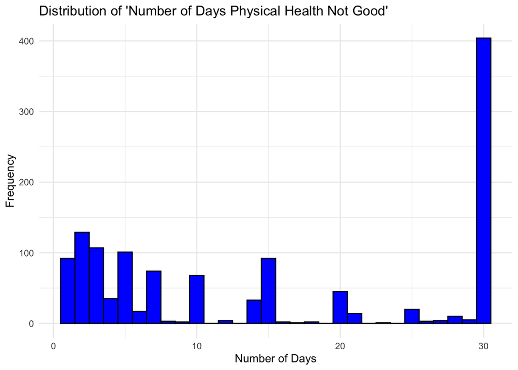

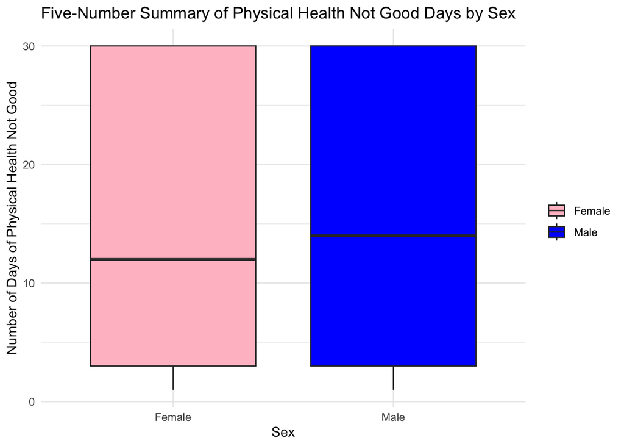

## Hypothesis Test

The null hypothesis is that there is no difference in the mean number of days of poor physical health between males and females.

The alternative hypothesis suggests that there is a difference, specifically that males report a greater number of days where their physical health is not good compared to females.

## Conclusion

As a researcher who came into this with a preconceived notion that gender is a determinant in health quality, these results served as a reminder that individual health experiences are not solely defined by gender.

Future research should consist of examining the impact of different variables, such as age, employment, or socio-economic status.